# Lab 3 Solutions

### Question 1 (2 pts)

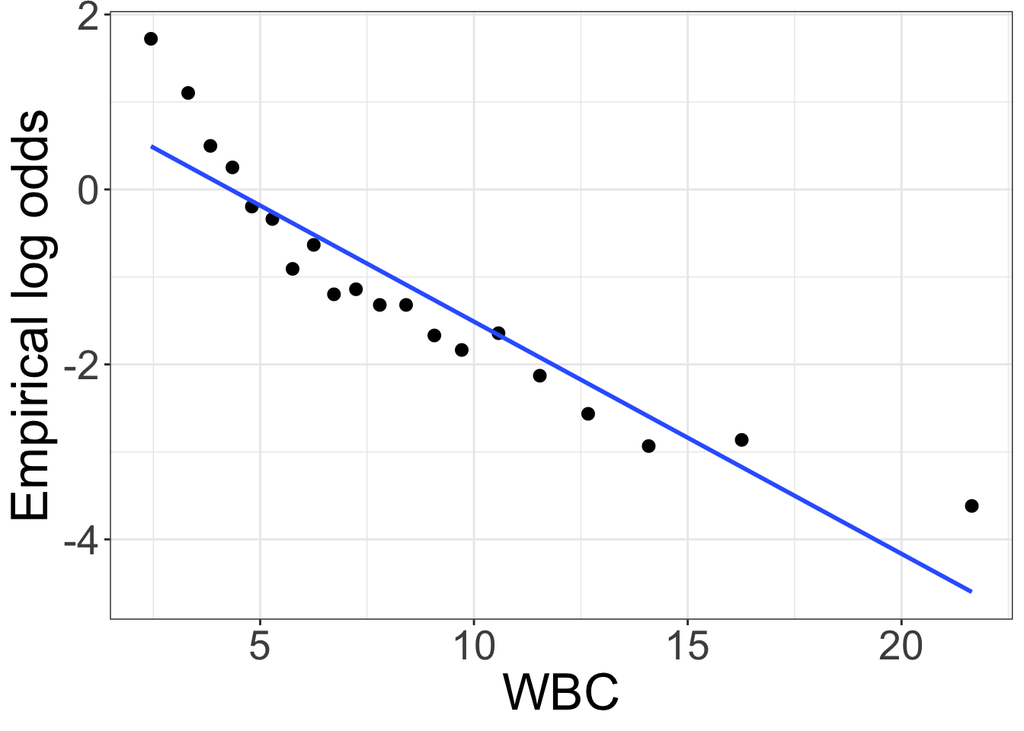

```r
logodds_plot(dengue, 20, "equal_size", "WBC", "Dengue")
```

While a linear relationship is an ok approximation, the relationship appears to be curved.

**Grading:** 1 pt for plot, 1pt for commenting on nonlinearity

### Question 2 (2 pts)

```r
library(gridExtra)
```

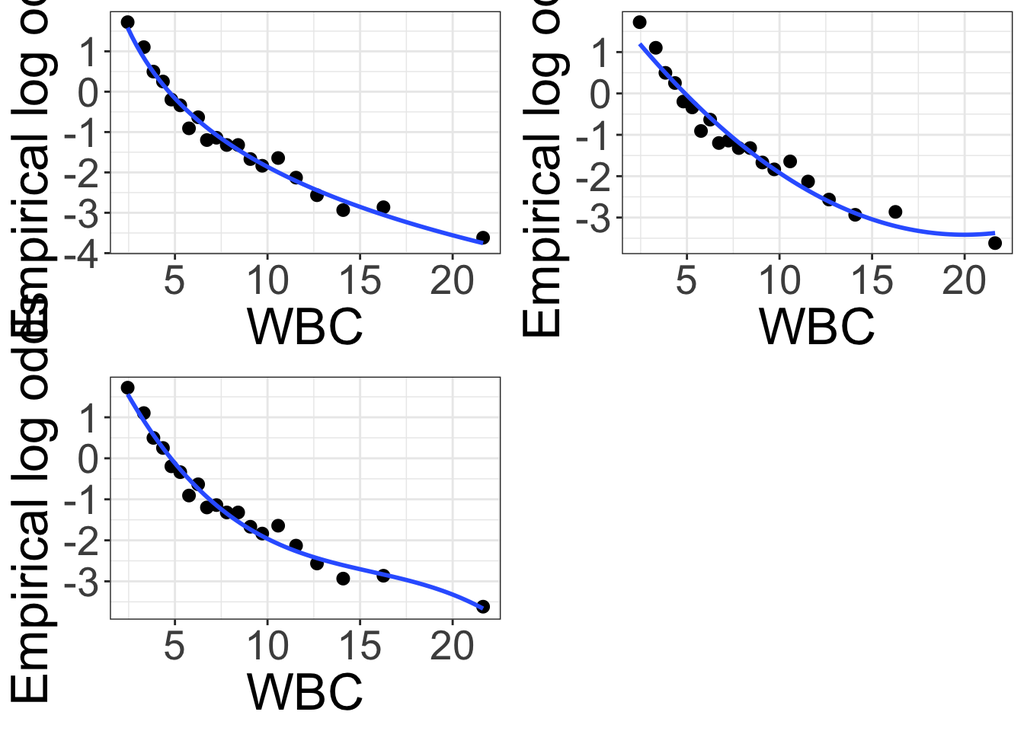

```r
p1 <- logodds_plot(dengue, 20, "equal_size", "WBC", "Dengue", reg_formula = y~log(x))
p2 <- logodds_plot(dengue, 20, "equal_size", "WBC", "Dengue", reg_formula = y~poly(x, 2))
p3 <- logodds_plot(dengue, 20, "equal_size", "WBC", "Dengue", reg_formula = y~poly(x, 3))
grid.arrange(p1, p2, p3, ncol=2)
```

I think the log transformation looks best here, though the polynomial transformation of order 2 is ok. I might be worried about overfitting with the polynomial transformation of order 3.

**Grading:** 1 pt for plots, 1 point for reasonable commentary (it is ok if their preferred transformation isn’t the log transformation)

### Question 3 (2 pts)

```r
model1 <- glm(Dengue ~ WBC, family=binomial, data=dengue)
summary(model1)$aic
```

```
## [1] 5533.825
```

```r
summary(model1)$deviance
```

```
## [1] 5529.825
```

```r
model2 <- glm(Dengue ~ log(WBC), family=binomial, data=dengue)
summary(model2)$aic
```

```
## [1] 5414.839
```

```r
summary(model2)$deviance
```

```
## [1] 5410.839
```

```r
model3 <- glm(Dengue ~ poly(WBC, 2), family=binomial, data=dengue)
summary(model3)$aic
```

```
## [1] 5471.628
```

```r
summary(model3)$deviance
```

```
## [1] 5465.628
```

```r
model4 <- glm(Dengue ~ poly(WBC, 3), family=binomial, data=dengue)
summary(model4)$aic
```

```
## [1] 5416.551
```

```r
summary(model4)$deviance
```

```
## [1] 5408.551
```

The log transformation has the smallest AIC, so we would choose the log transformation. The polynomial transformation of order 3 actually has the smallest deviance, but has a higher AIC because it has more terms.

**Grading:** 1 pt for AIC comparison, 1 pt for deviance comparison

### Question 4 (2 pts)

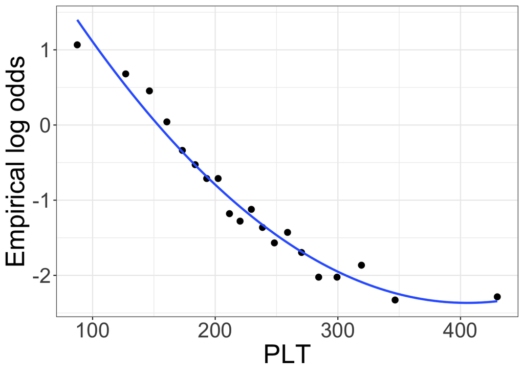

```r
logodds_plot(dengue, 20, "equal_size", "PLT", "Dengue", reg_formula = y ~ poly(x, 2))
```

It looks like a polynomial transformation of order 2 fits best here.

**Grading:** I’m ok with them choosing a different transformation instead. But a linear relationship doesn’t seem right.

### Question 5 (2 pts)

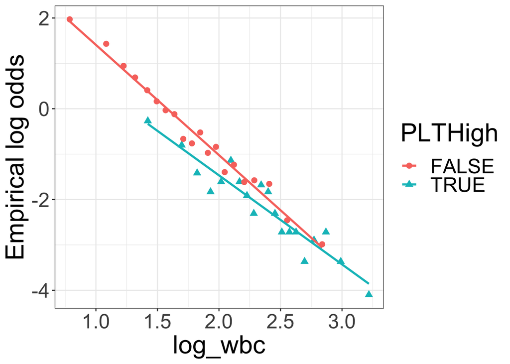

```r
dengue %>%
  mutate(log_wbc = log(WBC),
         PLTHigh = PLT > 250) %>%
  logodds_plot(20, "equal_size", x = "log_wbc", y = "Dengue",
               reg_formula = y ~ x, grouping = "PLTHigh")
```

There may be a small interaction between platelet count and white blood cell count, because the lines have slightly different slopes.

**Grading:** 1 pt for answer, 1 pt for reasoning. Either answer (there is or there isn’t an interaction) is acceptable, as long as they explain why.

### Question 6 (2 pts)

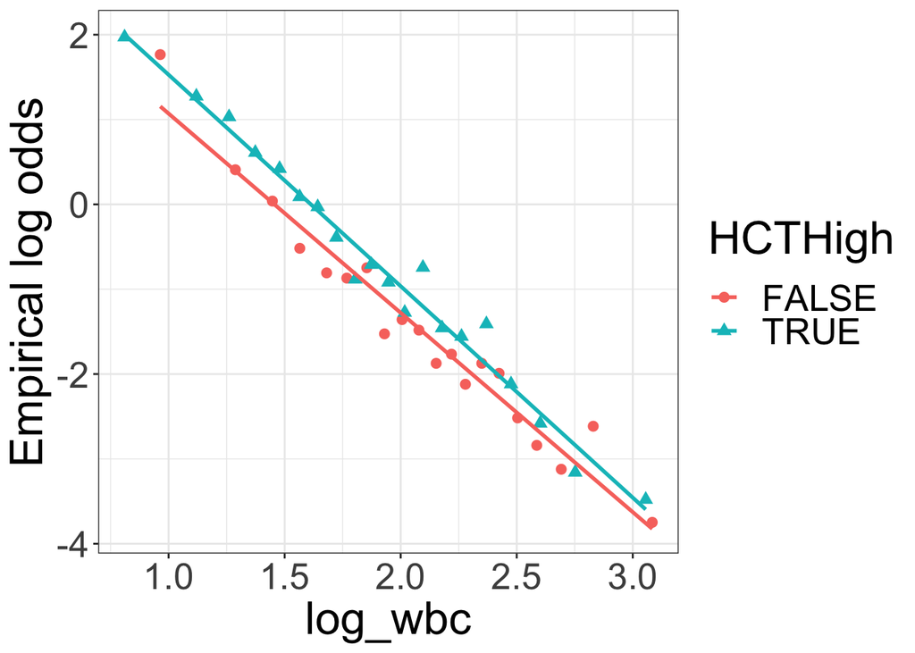

```r
dengue %>%
  mutate(log_wbc = log(WBC),
         HCTHigh = HCT > 38) %>%
  logodds_plot(20, "equal_size", x = "log_wbc", y = "Dengue",
               reg_formula = y ~ x, grouping = "HCTHigh")
```

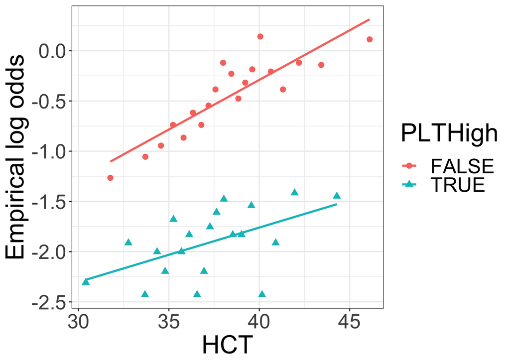

```r
dengue %>%
  mutate(PLTHigh = PLT > 250) %>%
  logodds_plot(20, "equal_size", x = "HCT", y = "Dengue",
               reg_formula = y ~ x, grouping = "PLTHigh")
```

**Grading:** 1 pt for each plot. It is ok if they use a polynomial transformation on PLT, if PLT is on the x-axis. They just have to have 1 plot with WBC and HCT, and 1 plot with PLT and HCT.

### Question 7 (2 pts)

```r
dengue_glm <- glm(Dengue ~ log(WBC) + I(PLT) + I(PLT^2) + HCT,
                  family = binomial, data = dengue)
summary(dengue_glm)
```

```
##
## Call:
## glm(formula = Dengue ~ log(WBC) + I(PLT) + I(PLT^2) + HCT, family = binomial,
##     data = dengue)
##
## Deviance Residuals:
##     Min       1Q   Median       3Q      Max
## -2.6334  -0.7177  -0.4164   0.6859   2.8216
##
## Coefficients:
##               Estimate Std. Error z value Pr(>|z|)
## (Intercept)  3.332e+00  4.737e-01   7.033 2.02e-12 ***
## log(WBC)    -2.079e+00  8.766e-02 -23.718  < 2e-16 ***
## I(PLT)      -1.474e-02  1.630e-03  -9.041  < 2e-16 ***
## I(PLT^2)     1.988e-05  3.053e-06   6.512 7.42e-11 ***
## HCT          4.948e-02  1.034e-02   4.785 1.71e-06 ***
## ---
## Signif. codes:  0 '***' 0.001 '**' 0.01 '*' 0.05 '.' 0.1 ' ' 1
##
## (Dispersion parameter for binomial family taken to be 1)
##
##     Null deviance: 6955.8  on 5719  degrees of freedom
## Residual deviance: 5256.3  on 5715  degrees of freedom
## AIC: 5266.3
##
## Number of Fisher Scoring iterations: 5
```

$\log \left( \dfrac{\widehat{\pi_i}}{1 - \widehat{\pi_i}} \right) = 3.332 - 2.079 \log(WBC)_i - 0.0147 PLT_i + 0.00002 PLT_i^2 + 0.05 HCT_i$

**Grading:** Lose 1 point for incorrect notation (e.g., missing subscripts, missing hats, etc.) Any combination of interaction terms is ok here. I didn’t put any in, but you certainly could (and you can make a good argument for putting them in based on AIC). However, they need a transformation for both PLT and WBC, otherwise lose 1 point. Lose 1 point if they use a binarized variable (e.g., PLTHigh) instead of the original.

### Question 8 (1 pt)

Yes, the AIC has decreased after adding PLT and HCT.

### Question 9 (2 pts)

```r
preds <- ifelse(predict(dengue_glm, type="response") > 0.5, 1, 0)
table("prediction" = preds, "truth" = dengue$Dengue)
```

```
##           truth
## prediction    0    1
##          0 3655  823
##          1  368  874
```

The accuracy of our model is (3655 + 874)/5720 = 0.79. This is a bit lower than the accuracy of the rapid test, which is about 0.91.

**Grading:** Their accuracy might be different from mine, if they fit a different model. That’s ok, if they calculate it correctly.

### Question 10 (2 pts)

The sensitivity is 874/(874 + 823) = 0.52. The specificity is 3655/(3655 + 368) = 0.91. Both numbers are lower than the sensitivity and specificity for the rapid test.

**Grading:** 1 pt for sensitivity, 1 pt for specificity. Their numbers might be different from mine, if they fit a different model. That’s ok, if they calculate them correctly from their confusion matrix.

### Question 11 (3 pts)

As we increase the threshold, sensitivity decreases and specificity increases. As we decrease the threshold, sensitivity increases and specificity decreases.

### Question 12 (2 pts)

The log likelihood is

$\log \left( \prod \limits_{i=1}^n \exp \{ - \dfrac{1}{2}(Y_i - \widehat{\beta}_0 - \widehat{\beta}_1 X_i)^2 \right) = -\frac{1}{2} \sum \limits_{i=1}^n (Y_i - \widehat{\beta}_0 - \widehat{\beta}_1 X_i)^2$

So the deviance ( $-2 \log L$ ) is $\sum \limits_{i=1}^n (Y_i - \widehat{\beta}_0 - \widehat{\beta}_1 X_i)^2$, which is the SSE.

**Grading:** 1 pt for log likelihood, 1 pt for deviance

### Question 13 (4 pts)

Since we don’t have $\beta_1$ or $X_i$, then the log likelihood is

$-\frac{1}{2} \sum \limits_{i=1}^n (Y_i - \widehat{\beta}_0)^2$

Taking the derivative, we get

$-\frac{1}{2} \sum \limits_{i=1}^n -2(Y_i - \widehat{\beta}_0) = \sum \limits_{i=1}^nY_i - n \widehat{\beta}_0$

We set this equal to 0 and solve for $\widehat{\beta}_0$, which gives

$\widehat{\beta}_0 = \frac{1}{n} \sum \limits_{i=1}^nY_i$

**Grading:** They have to show work to get full credit. 2 pts for taking the derivative, 2 pts for solving for $\widehat{\beta}_0$